# Ćwiczenie 1, część 2

## Kornel Romański

### Wstęp

Część druga jest kontynuacją ćwiczeni, w której poszukiwane są najelpsze wartości hiperparametrów.

### Etap 1

Na początku zbadane zostały następujące wartości:

- liczba warstw: 2 warstwy (256 i 14 neuronów), 3 warstwy (6000, 256 i 14 neuronów),
- sposób inicjalizacji wag i biasów: random_uniform, random_normal.

Dla pozostałych hiperparametrów przujęte zostały wartości:

- optymalizator: Adam,
- współczynnik uczenia: 0.001,
- liczba epok: 25,
- rozmiar paczki: 100.

Przebiegi uczenia dla każdej kombinacji parametrów znajdują się w załączniku raport2_etap1.html. Poniżej przedstawiono tabelę z wynikami najlepszej epoki (według miary F1Score) dla każdej kombinacji parametrów:

```python
# full code in notebooks
```

|  | layers | initialization | optimizer | lr | epochs | batch | epoch_num | val_loss | val_f1 | val_acc | total_time_s |
| --- | --- | --- | --- | --- | --- | --- | --- | --- | --- | --- | --- |
| 0 | 3 | random_normal | Adam | 0.001 | 25 | 100 | 25 | 2.3382 | 0.1691 | 0.2368 | 853.16 |
| 1 | 3 | random_uniform | Adam | 0.001 | 25 | 100 | 22 | 2.3569 | 0.1657 | 0.2257 | 856.35 |
| 2 | 2 | random_uniform | Adam | 0.001 | 25 | 100 | 24 | 2.4201 | 0.1102 | 0.2102 | 69.23 |
| 3 | 2 | random_normal | Adam | 0.001 | 25 | 100 | 23 | 2.4314 | 0.1008 | 0.2024 | 64.98 |

Najwyższą wartość F1Score uzyskano dla modelu z trzema warstwami oraz inicjalizacją random_normal. Przebieg uczenia z wykorzystaniem tych parametrów wyglądał następująco:

```
--MODEL--
Layers:  3
Initialization:  random_normal
Optimizer:  Adam
Learning rate:  0.001
Epochs:  25
Batch:  100

Best validation F1Score:  0.1691
Best validation Loss:  2.338200092315674
Best validation Accuracy:  0.2368

Mean epoch time (s):  34.13
Total time (s):  853.16
```

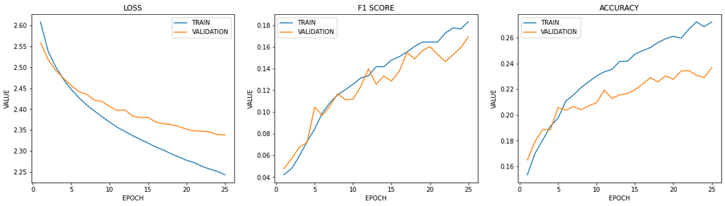

```python
# full code in notebooks
```

### Etap 2

Kolejnym etapem było zbadanie wpływu pozostałych hiperparametrów z zachowaniem znalezionych w poprzednim etapie parametrów. Zbadano:

- optymalizator: Adam, SGD,
- współczynnik uczenia: 0.001, 0.01,
- liczba epok: 20, 40,
- rozmiar paczki: 100, 500.

Przebiegi uczenia dla każdej kombinacji parametrów znajdują się w załączniku raport2_etap2.html. Poniżej przedstawiono tabelę z wynikami najlepszych epoki (według miary F1Score):

```python
# full code in notebooks
```

|  | layers | initialization | optimizer | lr | epochs | batch | epoch_num | val_loss | val_f1 | val_acc | total_time_s |
| --- | --- | --- | --- | --- | --- | --- | --- | --- | --- | --- | --- |
| 0 | 3 | random_normal | SGD | 0.01 | 40 | 100 | 39 | 2.4595 | 0.2753 | 0.2574 | 1358.68 |
| 1 | 3 | random_normal | Adam | 0.01 | 40 | 100 | 39 | 2.3872 | 0.2664 | 0.2891 | 1369.07 |
| 2 | 3 | random_normal | SGD | 0.01 | 20 | 100 | 13 | 2.3306 | 0.2148 | 0.2372 | 698.73 |
| 3 | 3 | random_normal | Adam | 0.01 | 20 | 100 | 19 | 2.2842 | 0.2127 | 0.2655 | 745.65 |
| 4 | 3 | random_normal | Adam | 0.01 | 40 | 500 | 40 | 2.3274 | 0.2055 | 0.2156 | 859.41 |
| 5 | 3 | random_normal | SGD | 0.001 | 40 | 100 | 38 | 2.3221 | 0.1989 | 0.2409 | 1345.27 |
| 6 | 3 | random_normal | SGD | 0.01 | 40 | 500 | 32 | 2.3038 | 0.1987 | 0.2449 | 857.54 |
| 7 | 3 | random_normal | Adam | 0.001 | 40 | 100 | 34 | 2.3261 | 0.1887 | 0.2355 | 1487.4 |
| 8 | 3 | random_normal | SGD | 0.01 | 20 | 500 | 20 | 2.3335 | 0.1832 | 0.2264 | 442.07 |
| 9 | 3 | random_normal | Adam | 0.01 | 20 | 500 | 17 | 2.3397 | 0.1814 | 0.2294 | 489.94 |
| 10 | 3 | random_normal | SGD | 0.001 | 20 | 100 | 20 | 2.3537 | 0.1684 | 0.2345 | 670.94 |
| 11 | 3 | random_normal | Adam | 0.001 | 20 | 100 | 20 | 2.3579 | 0.1463 | 0.2264 | 686.52 |
| 12 | 3 | random_normal | Adam | 0.001 | 40 | 500 | 39 | 2.4235 | 0.128 | 0.2136 | 995.52 |
| 13 | 3 | random_normal | SGD | 0.001 | 40 | 500 | 38 | 2.4329 | 0.1165 | 0.2004 | 892.73 |
| 14 | 3 | random_normal | SGD | 0.001 | 20 | 500 | 19 | 2.4814 | 0.0855 | 0.1876 | 427.43 |
| 15 | 3 | random_normal | Adam | 0.001 | 20 | 500 | 19 | 2.4841 | 0.0812 | 0.1825 | 492.22 |

Najlepsze wyniki uzyskano dla:

- optymalizator: SGD,
- współczynnik uczenia: 0.01,
- liczba epok: 40,
- rozmiar paczki: 100.

Prroces uczenia dla tego modelu wystąpał następująca

```
--MODEL--
Layers:  3
Initialization:  random_normal
Optimizer:  SGD
Learning rate:  0.01
Epochs:  40
Batch:  100

Best validation F1Score:  0.2753
Best validation Loss:  2.278700113296509
Best validation Accuracy:  0.2733

Mean epoch time (s):  33.97
Total time (s):  1358.68
```

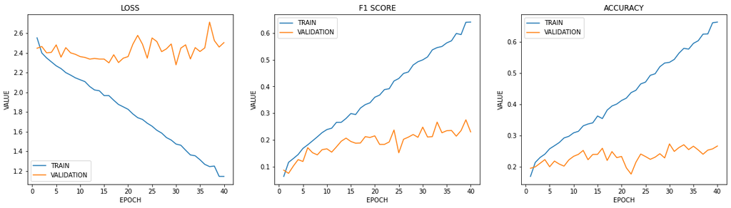

```python
# full code in notebooks
```

### Wyniki na zbiorze testowym

Najlepszy znaleziony model sprawdzono na zbiorze testowym i otrzymano wyniki:

```python
# full code in notebooks
```

```
Test F1: 0.2436798806771498
```

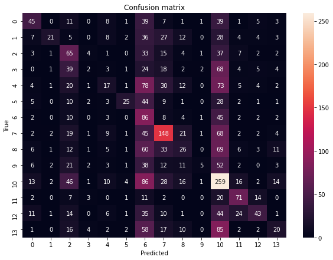

```python
# full code in notebooks
```

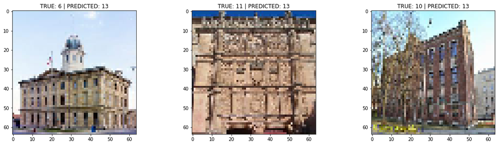

```python
# full code in notebooks
```

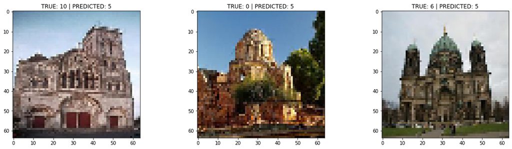

```python
# full code in notebooks
```

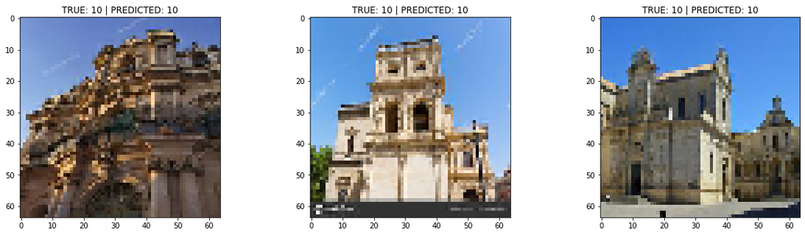

```python
# full code in notebooks
```